# Risk Factor Analysis

## Outcome Variable

**Outcome Variable:** haz

## Predictor Variables

**Intervention Variable:** fhtcm

**Adjustment Set:**

- arm
- W_mage
- W_fage
- meducyrs
- feducyrs
- W_mhtcm
- W_mwtkg
- W_mbmi
- single
- W_gagebrth
- W_birthwt
- W_birthlen
- vagbrth
- delta_W_mage
- delta_W_fage
- delta_meducyrs
- delta_feducyrs
- delta_W_mhtcm
- delta_W_mwtkg
- delta_W_mbmi
- delta_single
- delta_W_gagebrth
- delta_W_birthwt
- delta_W_birthlen
- delta_vagbrth

## Stratifying Variables

The analysis was stratified on these variable(s):

- agecat
- studyid
- country

## Data Summary

| agecat | studyid | country | fhtcm | n_cell | n |
| --- | --- | --- | --- | --- | --- |
| 6 months | ki1000304b-SAS-CompFeed | INDIA | >=167 cm | 369 | 807 |
| 6 months | ki1000304b-SAS-CompFeed | INDIA | <162 cm | 194 | 807 |
| 6 months | ki1000304b-SAS-CompFeed | INDIA | [162-167) cm | 244 | 807 |
| 6 months | ki1000304b-SAS-FoodSuppl | INDIA | >=167 cm | 102 | 372 |
| 6 months | ki1000304b-SAS-FoodSuppl | INDIA | <162 cm | 148 | 372 |
| 6 months | ki1000304b-SAS-FoodSuppl | INDIA | [162-167) cm | 122 | 372 |
| 6 months | ki1101329-Keneba | GAMBIA | >=167 cm | 979 | 1511 |
| 6 months | ki1101329-Keneba | GAMBIA | <162 cm | 113 | 1511 |
| 6 months | ki1101329-Keneba | GAMBIA | [162-167) cm | 419 | 1511 |
| 6 months | ki1119695-PROBIT | BELARUS | >=167 cm | 11146 | 11895 |
| 6 months | ki1119695-PROBIT | BELARUS | <162 cm | 156 | 11895 |
| 6 months | ki1119695-PROBIT | BELARUS | [162-167) cm | 593 | 11895 |
| 6 months | ki1135781-COHORTS | GUATEMALA | >=167 cm | 45 | 336 |
| 6 months | ki1135781-COHORTS | GUATEMALA | <162 cm | 197 | 336 |
| 6 months | ki1135781-COHORTS | GUATEMALA | [162-167) cm | 94 | 336 |
| 24 months | ki1101329-Keneba | GAMBIA | >=167 cm | 821 | 1297 |
| 24 months | ki1101329-Keneba | GAMBIA | <162 cm | 97 | 1297 |
| 24 months | ki1101329-Keneba | GAMBIA | [162-167) cm | 379 | 1297 |
| 24 months | ki1119695-PROBIT | BELARUS | >=167 cm | 3445 | 3670 |
| 24 months | ki1119695-PROBIT | BELARUS | <162 cm | 53 | 3670 |
| 24 months | ki1119695-PROBIT | BELARUS | [162-167) cm | 172 | 3670 |
| 24 months | ki1135781-COHORTS | GUATEMALA | >=167 cm | 72 | 528 |
| 24 months | ki1135781-COHORTS | GUATEMALA | <162 cm | 307 | 528 |
| 24 months | ki1135781-COHORTS | GUATEMALA | [162-167) cm | 149 | 528 |

The following strata were considered:

- agecat: 24 months, studyid: ki1101329-Keneba, country: GAMBIA
- agecat: 24 months, studyid: ki1119695-PROBIT, country: BELARUS
- agecat: 24 months, studyid: ki1135781-COHORTS, country: GUATEMALA
- agecat: 6 months, studyid: ki1000304b-SAS-CompFeed, country: INDIA
- agecat: 6 months, studyid: ki1000304b-SAS-FoodSuppl, country: INDIA
- agecat: 6 months, studyid: ki1101329-Keneba, country: GAMBIA
- agecat: 6 months, studyid: ki1119695-PROBIT, country: BELARUS
- agecat: 6 months, studyid: ki1135781-COHORTS, country: GUATEMALA

## Methods Detail

We’re interested in the causal parameters $E[Y_a]$ for all values of $a \in \mathcal{A}$. These parameters represent the mean outcome if, possibly contrary to fact, we intervened to set all units to have $A=a$. Under the randomization and positivity assumptions, these are identified by the statistical parameters $\psi_a=E_W[E_{Y|A,W}(Y|A=a,W)]$. In addition, we’re interested in the mean of $Y$, $E[Y]$ under no intervention (the observed mean). We will estimate these parameters by using SuperLearner to fit the relevant likelihood factors – $E_{Y|A,W}(Y|A=a,W)$ and $p(A=a|W)$, and then updating our likelihood fit using a joint TMLE.

For unadjusted analyses ($W=\{\}$), initial likelihoods were estimated using Lrnr_glm to estimate the simple $E(Y|A)$ and Lrnr_mean to estimate $p(A)$. For adjusted analyses, a small library containing Lrnr_glmnet, Lrnr_xgboost, and Lrnr_mean was used.

Having estimated these parameters, we will then use the delta method to estimate relative risks and attributable risks relative to a prespecified baseline level of $A$.

# Results Detail

## Results Plots

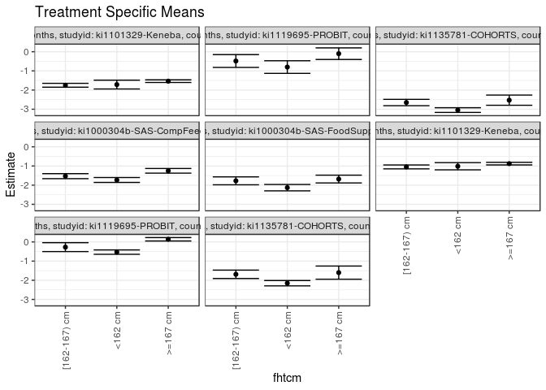

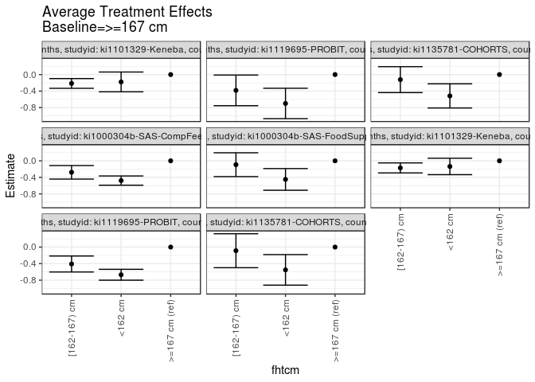

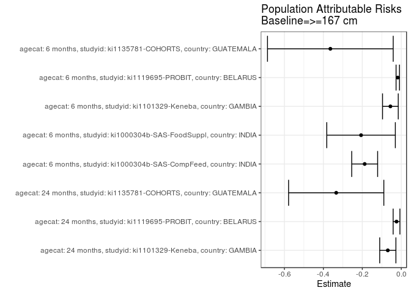

## Results Table

### Parameter: TSM

| agecat | studyid | country | intervention_level | baseline_level | estimate | ci_lower | ci_upper |
| --- | --- | --- | --- | --- | --- | --- | --- |
| 6 months | ki1000304b-SAS-CompFeed | INDIA | >=167 cm | NA | -1.2522183 | -1.3736784 | -1.1307581 |
| 6 months | ki1000304b-SAS-CompFeed | INDIA | <162 cm | NA | -1.7300584 | -1.8574818 | -1.6026351 |
| 6 months | ki1000304b-SAS-CompFeed | INDIA | [162-167) cm | NA | -1.5304470 | -1.6613287 | -1.3995652 |
| 6 months | ki1000304b-SAS-FoodSuppl | INDIA | >=167 cm | NA | -1.6807250 | -1.8844837 | -1.4769663 |
| 6 months | ki1000304b-SAS-FoodSuppl | INDIA | <162 cm | NA | -2.1304273 | -2.2967326 | -1.9641220 |
| 6 months | ki1000304b-SAS-FoodSuppl | INDIA | [162-167) cm | NA | -1.7741284 | -1.9800079 | -1.5682490 |
| 6 months | ki1101329-Keneba | GAMBIA | >=167 cm | NA | -0.8764042 | -0.9445311 | -0.8082773 |
| 6 months | ki1101329-Keneba | GAMBIA | <162 cm | NA | -1.0126454 | -1.1998425 | -0.8254484 |
| 6 months | ki1101329-Keneba | GAMBIA | [162-167) cm | NA | -1.0479926 | -1.1502999 | -0.9456852 |
| 6 months | ki1119695-PROBIT | BELARUS | >=167 cm | NA | 0.1382969 | 0.0496441 | 0.2269497 |
| 6 months | ki1119695-PROBIT | BELARUS | <162 cm | NA | -0.5309914 | -0.6448908 | -0.4170920 |
| 6 months | ki1119695-PROBIT | BELARUS | [162-167) cm | NA | -0.2706640 | -0.5035536 | -0.0377743 |
| 6 months | ki1135781-COHORTS | GUATEMALA | >=167 cm | NA | -1.6012119 | -1.9446215 | -1.2578023 |
| 6 months | ki1135781-COHORTS | GUATEMALA | <162 cm | NA | -2.1526627 | -2.2916041 | -2.0137214 |
| 6 months | ki1135781-COHORTS | GUATEMALA | [162-167) cm | NA | -1.6889112 | -1.9088032 | -1.4690193 |
| 24 months | ki1101329-Keneba | GAMBIA | >=167 cm | NA | -1.5358071 | -1.6048028 | -1.4668115 |
| 24 months | ki1101329-Keneba | GAMBIA | <162 cm | NA | -1.7139312 | -1.9439154 | -1.4839470 |
| 24 months | ki1101329-Keneba | GAMBIA | [162-167) cm | NA | -1.7506332 | -1.8512025 | -1.6500639 |
| 24 months | ki1119695-PROBIT | BELARUS | >=167 cm | NA | -0.1023201 | -0.4048723 | 0.2002320 |
| 24 months | ki1119695-PROBIT | BELARUS | <162 cm | NA | -0.8008833 | -1.1303272 | -0.4714394 |
| 24 months | ki1119695-PROBIT | BELARUS | [162-167) cm | NA | -0.4845697 | -0.8193754 | -0.1497640 |
| 24 months | ki1135781-COHORTS | GUATEMALA | >=167 cm | NA | -2.5288507 | -2.7949932 | -2.2627082 |
| 24 months | ki1135781-COHORTS | GUATEMALA | <162 cm | NA | -3.0449355 | -3.1667389 | -2.9231322 |
| 24 months | ki1135781-COHORTS | GUATEMALA | [162-167) cm | NA | -2.6512885 | -2.8166409 | -2.4859360 |

### Parameter: E(Y)

| agecat | studyid | country | intervention_level | baseline_level | estimate | ci_lower | ci_upper |
| --- | --- | --- | --- | --- | --- | --- | --- |
| 6 months | ki1000304b-SAS-CompFeed | INDIA | NA | NA | -1.4400743 | -1.5370187 | -1.3431300 |
| 6 months | ki1000304b-SAS-FoodSuppl | INDIA | NA | NA | -1.8871505 | -1.9993302 | -1.7749709 |
| 6 months | ki1101329-Keneba | GAMBIA | NA | NA | -0.9321551 | -0.9872314 | -0.8770788 |
| 6 months | ki1119695-PROBIT | BELARUS | NA | NA | 0.1203779 | 0.0296502 | 0.2111056 |
| 6 months | ki1135781-COHORTS | GUATEMALA | NA | NA | -1.9652976 | -2.0794998 | -1.8510954 |
| 24 months | ki1101329-Keneba | GAMBIA | NA | NA | -1.6048736 | -1.6613661 | -1.5483810 |
| 24 months | ki1119695-PROBIT | BELARUS | NA | NA | -0.1266303 | -0.4286611 | 0.1754004 |
| 24 months | ki1135781-COHORTS | GUATEMALA | NA | NA | -2.8628788 | -2.9576712 | -2.7680864 |

### Parameter: ATE

| agecat | studyid | country | intervention_level | baseline_level | estimate | ci_lower | ci_upper |
| --- | --- | --- | --- | --- | --- | --- | --- |
| 6 months | ki1000304b-SAS-CompFeed | INDIA | >=167 cm | >=167 cm | 0.0000000 | 0.0000000 | 0.0000000 |
| 6 months | ki1000304b-SAS-CompFeed | INDIA | <162 cm | >=167 cm | -0.4778402 | -0.5900324 | -0.3656479 |
| 6 months | ki1000304b-SAS-CompFeed | INDIA | [162-167) cm | >=167 cm | -0.2782287 | -0.4415167 | -0.1149407 |
| 6 months | ki1000304b-SAS-FoodSuppl | INDIA | >=167 cm | >=167 cm | 0.0000000 | 0.0000000 | 0.0000000 |
| 6 months | ki1000304b-SAS-FoodSuppl | INDIA | <162 cm | >=167 cm | -0.4497023 | -0.7118396 | -0.1875651 |
| 6 months | ki1000304b-SAS-FoodSuppl | INDIA | [162-167) cm | >=167 cm | -0.0934035 | -0.3816414 | 0.1948345 |
| 6 months | ki1101329-Keneba | GAMBIA | >=167 cm | >=167 cm | 0.0000000 | 0.0000000 | 0.0000000 |
| 6 months | ki1101329-Keneba | GAMBIA | <162 cm | >=167 cm | -0.1362412 | -0.3347063 | 0.0622238 |
| 6 months | ki1101329-Keneba | GAMBIA | [162-167) cm | >=167 cm | -0.1715884 | -0.2929114 | -0.0502654 |
| 6 months | ki1119695-PROBIT | BELARUS | >=167 cm | >=167 cm | 0.0000000 | 0.0000000 | 0.0000000 |
| 6 months | ki1119695-PROBIT | BELARUS | <162 cm | >=167 cm | -0.6692883 | -0.8007370 | -0.5378396 |
| 6 months | ki1119695-PROBIT | BELARUS | [162-167) cm | >=167 cm | -0.4089609 | -0.6023078 | -0.2156140 |
| 6 months | ki1135781-COHORTS | GUATEMALA | >=167 cm | >=167 cm | 0.0000000 | 0.0000000 | 0.0000000 |
| 6 months | ki1135781-COHORTS | GUATEMALA | <162 cm | >=167 cm | -0.5514508 | -0.9214955 | -0.1814061 |
| 6 months | ki1135781-COHORTS | GUATEMALA | [162-167) cm | >=167 cm | -0.0876993 | -0.4982538 | 0.3228552 |
| 24 months | ki1101329-Keneba | GAMBIA | >=167 cm | >=167 cm | 0.0000000 | 0.0000000 | 0.0000000 |
| 24 months | ki1101329-Keneba | GAMBIA | <162 cm | >=167 cm | -0.1781241 | -0.4173945 | 0.0611463 |
| 24 months | ki1101329-Keneba | GAMBIA | [162-167) cm | >=167 cm | -0.2148260 | -0.3328791 | -0.0967730 |
| 24 months | ki1119695-PROBIT | BELARUS | >=167 cm | >=167 cm | 0.0000000 | 0.0000000 | 0.0000000 |
| 24 months | ki1119695-PROBIT | BELARUS | <162 cm | >=167 cm | -0.6985632 | -1.0661145 | -0.3310118 |
| 24 months | ki1119695-PROBIT | BELARUS | [162-167) cm | >=167 cm | -0.3822496 | -0.7524907 | -0.0120084 |
| 24 months | ki1135781-COHORTS | GUATEMALA | >=167 cm | >=167 cm | 0.0000000 | 0.0000000 | 0.0000000 |
| 24 months | ki1135781-COHORTS | GUATEMALA | <162 cm | >=167 cm | -0.5160849 | -0.8082950 | -0.2238747 |
| 24 months | ki1135781-COHORTS | GUATEMALA | [162-167) cm | >=167 cm | -0.1224378 | -0.4355401 | 0.1906644 |

### Parameter: PAR

| agecat | studyid | country | intervention_level | baseline_level | estimate | ci_lower | ci_upper |
| --- | --- | --- | --- | --- | --- | --- | --- |
| 6 months | ki1000304b-SAS-CompFeed | INDIA | >=167 cm | NA | -0.1878561 | -0.2544307 | -0.1212815 |
| 6 months | ki1000304b-SAS-FoodSuppl | INDIA | >=167 cm | NA | -0.2064256 | -0.3824499 | -0.0304012 |
| 6 months | ki1101329-Keneba | GAMBIA | >=167 cm | NA | -0.0557509 | -0.0960813 | -0.0154206 |
| 6 months | ki1119695-PROBIT | BELARUS | >=167 cm | NA | -0.0179190 | -0.0266578 | -0.0091802 |
| 6 months | ki1135781-COHORTS | GUATEMALA | >=167 cm | NA | -0.3640857 | -0.6868472 | -0.0413243 |
| 24 months | ki1101329-Keneba | GAMBIA | >=167 cm | NA | -0.0690664 | -0.1106633 | -0.0274696 |
| 24 months | ki1119695-PROBIT | BELARUS | >=167 cm | NA | -0.0243102 | -0.0416968 | -0.0069236 |
| 24 months | ki1135781-COHORTS | GUATEMALA | >=167 cm | NA | -0.3340281 | -0.5785603 | -0.0894959 |